# Risk Factor Analysis

## Outcome Variable

**Outcome Variable:** stunted

## Predictor Variables

**Intervention Variable:** tr

**Adjustment Set:**

unadjusted

## Stratifying Variables

The analysis was stratified on these variable(s):

- cleanck
- agecat
- studyid
- country

## Data Summary

| cleanck | agecat | studyid | country | tr | stunted | n_cell | n |
| --- | --- | --- | --- | --- | --- | --- | --- |
| 0 | 24 months | ki1000111-WASH-Kenya | KENYA | Control | 0 | 518 | 2230 |
| 0 | 24 months | ki1000111-WASH-Kenya | KENYA | Control | 1 | 232 | 2230 |
| 0 | 24 months | ki1000111-WASH-Kenya | KENYA | LNS | 0 | 352 | 2230 |
| 0 | 24 months | ki1000111-WASH-Kenya | KENYA | LNS | 1 | 144 | 2230 |
| 0 | 24 months | ki1000111-WASH-Kenya | KENYA | Other | 0 | 665 | 2230 |
| 0 | 24 months | ki1000111-WASH-Kenya | KENYA | Other | 1 | 319 | 2230 |
| 0 | 6 months | ki1000111-WASH-Kenya | KENYA | Control | 0 | 23 | 73 |
| 0 | 6 months | ki1000111-WASH-Kenya | KENYA | Control | 1 | 2 | 73 |
| 0 | 6 months | ki1000111-WASH-Kenya | KENYA | LNS | 0 | 11 | 73 |
| 0 | 6 months | ki1000111-WASH-Kenya | KENYA | LNS | 1 | 3 | 73 |
| 0 | 6 months | ki1000111-WASH-Kenya | KENYA | Other | 0 | 28 | 73 |
| 0 | 6 months | ki1000111-WASH-Kenya | KENYA | Other | 1 | 6 | 73 |
| 1 | 24 months | ki1000111-WASH-Kenya | KENYA | Control | 0 | 7 | 31 |
| 1 | 24 months | ki1000111-WASH-Kenya | KENYA | Control | 1 | 0 | 31 |
| 1 | 24 months | ki1000111-WASH-Kenya | KENYA | LNS | 0 | 2 | 31 |
| 1 | 24 months | ki1000111-WASH-Kenya | KENYA | LNS | 1 | 2 | 31 |
| 1 | 24 months | ki1000111-WASH-Kenya | KENYA | Other | 0 | 19 | 31 |
| 1 | 24 months | ki1000111-WASH-Kenya | KENYA | Other | 1 | 1 | 31 |
| 1 | 6 months | ki1000111-WASH-Kenya | KENYA | LNS | 0 | 1 | 1 |
| 0 | 6 months | ki1000125-AgaKhanUniv | PAKISTAN | Control | 0 | 108 | 219 |
| 0 | 6 months | ki1000125-AgaKhanUniv | PAKISTAN | Control | 1 | 50 | 219 |
| 0 | 6 months | ki1000125-AgaKhanUniv | PAKISTAN | Maternal | 0 | 45 | 219 |
| 0 | 6 months | ki1000125-AgaKhanUniv | PAKISTAN | Maternal | 1 | 16 | 219 |
| 1 | 6 months | ki1000125-AgaKhanUniv | PAKISTAN | Control | 0 | 16 | 48 |
| 1 | 6 months | ki1000125-AgaKhanUniv | PAKISTAN | Control | 1 | 5 | 48 |
| 1 | 6 months | ki1000125-AgaKhanUniv | PAKISTAN | Maternal | 0 | 23 | 48 |
| 1 | 6 months | ki1000125-AgaKhanUniv | PAKISTAN | Maternal | 1 | 4 | 48 |
| 0 | 24 months | ki1000125-AgaKhanUniv | PAKISTAN | Control | 1 | 1 | 1 |
| 0 | Birth | ki1000125-AgaKhanUniv | PAKISTAN | Control | 0 | 2 | 4 |
| 0 | Birth | ki1000125-AgaKhanUniv | PAKISTAN | Maternal | 0 | 2 | 4 |
| 1 | 6 months | ki1000304-VITAMIN-A | INDIA | Control | 0 | 773 | 2386 |
| 1 | 6 months | ki1000304-VITAMIN-A | INDIA | Control | 1 | 432 | 2386 |
| 1 | 6 months | ki1000304-VITAMIN-A | INDIA | VitA | 0 | 791 | 2386 |
| 1 | 6 months | ki1000304-VITAMIN-A | INDIA | VitA | 1 | 390 | 2386 |
| 0 | 6 months | ki1000304-VITAMIN-A | INDIA | Control | 0 | 40 | 122 |
| 0 | 6 months | ki1000304-VITAMIN-A | INDIA | Control | 1 | 20 | 122 |
| 0 | 6 months | ki1000304-VITAMIN-A | INDIA | VitA | 0 | 40 | 122 |
| 0 | 6 months | ki1000304-VITAMIN-A | INDIA | VitA | 1 | 22 | 122 |
| 1 | 6 months | ki1017093b-PROVIDE | BANGLADESH | Control | 0 | 6 | 37 |
| 1 | 6 months | ki1017093b-PROVIDE | BANGLADESH | Control | 1 | 2 | 37 |
| 1 | 6 months | ki1017093b-PROVIDE | BANGLADESH | Other | 0 | 24 | 37 |
| 1 | 6 months | ki1017093b-PROVIDE | BANGLADESH | Other | 1 | 5 | 37 |
| 0 | 6 months | ki1017093b-PROVIDE | BANGLADESH | Control | 0 | 2 | 9 |
| 0 | 6 months | ki1017093b-PROVIDE | BANGLADESH | Control | 1 | 0 | 9 |
| 0 | 6 months | ki1017093b-PROVIDE | BANGLADESH | Other | 0 | 4 | 9 |
| 0 | 6 months | ki1017093b-PROVIDE | BANGLADESH | Other | 1 | 3 | 9 |
| 1 | 24 months | ki1017093b-PROVIDE | BANGLADESH | Other | 0 | 2 | 2 |
| 0 | 6 months | ki1148112-iLiNS-DOSE | MALAWI | Control | 0 | 204 | 1802 |
| 0 | 6 months | ki1148112-iLiNS-DOSE | MALAWI | Control | 1 | 97 | 1802 |
| 0 | 6 months | ki1148112-iLiNS-DOSE | MALAWI | LNS | 0 | 1054 | 1802 |
| 0 | 6 months | ki1148112-iLiNS-DOSE | MALAWI | LNS | 1 | 447 | 1802 |
| 0 | 24 months | ki1148112-iLiNS-DOSE | MALAWI | Control | 0 | 62 | 766 |
| 0 | 24 months | ki1148112-iLiNS-DOSE | MALAWI | Control | 1 | 65 | 766 |
| 0 | 24 months | ki1148112-iLiNS-DOSE | MALAWI | LNS | 0 | 318 | 766 |
| 0 | 24 months | ki1148112-iLiNS-DOSE | MALAWI | LNS | 1 | 321 | 766 |
| 1 | 6 months | ki1148112-iLiNS-DOSE | MALAWI | LNS | 0 | 8 | 9 |
| 1 | 6 months | ki1148112-iLiNS-DOSE | MALAWI | LNS | 1 | 1 | 9 |
| 1 | 24 months | ki1148112-iLiNS-DOSE | MALAWI | LNS | 0 | 1 | 2 |
| 1 | 24 months | ki1148112-iLiNS-DOSE | MALAWI | LNS | 1 | 1 | 2 |
| 0 | 6 months | ki1148112-iLiNS-DYAD-M | MALAWI | Control | 0 | 78 | 322 |
| 0 | 6 months | ki1148112-iLiNS-DYAD-M | MALAWI | Control | 1 | 22 | 322 |
| 0 | 6 months | ki1148112-iLiNS-DYAD-M | MALAWI | Maternal | 0 | 175 | 322 |
| 0 | 6 months | ki1148112-iLiNS-DYAD-M | MALAWI | Maternal | 1 | 47 | 322 |
| 0 | 24 months | ki1148112-iLiNS-DYAD-M | MALAWI | Control | 0 | 0 | 10 |
| 0 | 24 months | ki1148112-iLiNS-DYAD-M | MALAWI | Control | 1 | 2 | 10 |
| 0 | 24 months | ki1148112-iLiNS-DYAD-M | MALAWI | Maternal | 0 | 4 | 10 |
| 0 | 24 months | ki1148112-iLiNS-DYAD-M | MALAWI | Maternal | 1 | 4 | 10 |
| 0 | 6 months | iLiNS_DYADM_LNS | MALAWI | Control | 0 | 78 | 208 |
| 0 | 6 months | iLiNS_DYADM_LNS | MALAWI | Control | 1 | 22 | 208 |
| 0 | 6 months | iLiNS_DYADM_LNS | MALAWI | LNS | 0 | 90 | 208 |
| 0 | 6 months | iLiNS_DYADM_LNS | MALAWI | LNS | 1 | 18 | 208 |
| 0 | 24 months | iLiNS_DYADM_LNS | MALAWI | Control | 0 | 0 | 6 |
| 0 | 24 months | iLiNS_DYADM_LNS | MALAWI | Control | 1 | 2 | 6 |
| 0 | 24 months | iLiNS_DYADM_LNS | MALAWI | LNS | 0 | 2 | 6 |
| 0 | 24 months | iLiNS_DYADM_LNS | MALAWI | LNS | 1 | 2 | 6 |

The following strata were considered:

- cleanck: 0, agecat: 24 months, studyid: iLiNS_DYADM_LNS, country: MALAWI
- cleanck: 0, agecat: 24 months, studyid: ki1000111-WASH-Kenya, country: KENYA
- cleanck: 0, agecat: 24 months, studyid: ki1000125-AgaKhanUniv, country: PAKISTAN
- cleanck: 0, agecat: 24 months, studyid: ki1148112-iLiNS-DOSE, country: MALAWI
- cleanck: 0, agecat: 24 months, studyid: ki1148112-iLiNS-DYAD-M, country: MALAWI
- cleanck: 0, agecat: 6 months, studyid: iLiNS_DYADM_LNS, country: MALAWI
- cleanck: 0, agecat: 6 months, studyid: ki1000111-WASH-Kenya, country: KENYA
- cleanck: 0, agecat: 6 months, studyid: ki1000125-AgaKhanUniv, country: PAKISTAN
- cleanck: 0, agecat: 6 months, studyid: ki1000304-VITAMIN-A, country: INDIA
- cleanck: 0, agecat: 6 months, studyid: ki1017093b-PROVIDE, country: BANGLADESH
- cleanck: 0, agecat: 6 months, studyid: ki1148112-iLiNS-DOSE, country: MALAWI
- cleanck: 0, agecat: 6 months, studyid: ki1148112-iLiNS-DYAD-M, country: MALAWI
- cleanck: 0, agecat: Birth, studyid: ki1000125-AgaKhanUniv, country: PAKISTAN
- cleanck: 1, agecat: 24 months, studyid: ki1000111-WASH-Kenya, country: KENYA
- cleanck: 1, agecat: 24 months, studyid: ki1017093b-PROVIDE, country: BANGLADESH
- cleanck: 1, agecat: 24 months, studyid: ki1148112-iLiNS-DOSE, country: MALAWI
- cleanck: 1, agecat: 6 months, studyid: ki1000111-WASH-Kenya, country: KENYA
- cleanck: 1, agecat: 6 months, studyid: ki1000125-AgaKhanUniv, country: PAKISTAN
- cleanck: 1, agecat: 6 months, studyid: ki1000304-VITAMIN-A, country: INDIA
- cleanck: 1, agecat: 6 months, studyid: ki1017093b-PROVIDE, country: BANGLADESH
- cleanck: 1, agecat: 6 months, studyid: ki1148112-iLiNS-DOSE, country: MALAWI

### Dropped Strata

Some strata were dropped due to rare outcomes:

- cleanck: 0, agecat: 6 months, studyid: ki1000111-WASH-Kenya, country: KENYA
- cleanck: 1, agecat: 24 months, studyid: ki1000111-WASH-Kenya, country: KENYA
- cleanck: 1, agecat: 6 months, studyid: ki1000111-WASH-Kenya, country: KENYA
- cleanck: 1, agecat: 6 months, studyid: ki1000125-AgaKhanUniv, country: PAKISTAN
- cleanck: 0, agecat: 24 months, studyid: ki1000125-AgaKhanUniv, country: PAKISTAN
- cleanck: 0, agecat: Birth, studyid: ki1000125-AgaKhanUniv, country: PAKISTAN
- cleanck: 1, agecat: 6 months, studyid: ki1017093b-PROVIDE, country: BANGLADESH
- cleanck: 0, agecat: 6 months, studyid: ki1017093b-PROVIDE, country: BANGLADESH
- cleanck: 1, agecat: 24 months, studyid: ki1017093b-PROVIDE, country: BANGLADESH
- cleanck: 1, agecat: 6 months, studyid: ki1148112-iLiNS-DOSE, country: MALAWI
- cleanck: 1, agecat: 24 months, studyid: ki1148112-iLiNS-DOSE, country: MALAWI
- cleanck: 0, agecat: 24 months, studyid: ki1148112-iLiNS-DYAD-M, country: MALAWI
- cleanck: 0, agecat: 24 months, studyid: iLiNS_DYADM_LNS, country: MALAWI

## Methods Detail

We’re interested in the causal parameters $E[Y_a]$ for all values of $a \in \mathcal{A}$. These parameters represent the mean outcome if, possibly contrary to fact, we intervened to set all units to have $A=a$. Under the randomization and positivity assumptions, these are identified by the statistical parameters $\psi_a=E_W[E_{Y|A,W}(Y|A=a,W)]$. In addition, we’re interested in the mean of $Y$, $E[Y]$ under no intervention (the observed mean). We will estimate these parameters by using SuperLearner to fit the relevant likelihood factors – $E_{Y|A,W}(Y|A=a,W)$ and $p(A=a|W)$, and then updating our likelihood fit using a joint TMLE.

For unadjusted analyses ($W=\{\}$), initial likelihoods were estimated using Lrnr_glm to estimate the simple $E(Y|A)$ and Lrnr_mean to estimate $p(A)$. For adjusted analyses, a small library containing Lrnr_glmnet, Lrnr_xgboost, and Lrnr_mean was used.

Having estimated these parameters, we will then use the delta method to estimate relative risks and attributable risks relative to a prespecified baseline level of $A$.

# Results Detail

## Results Plots

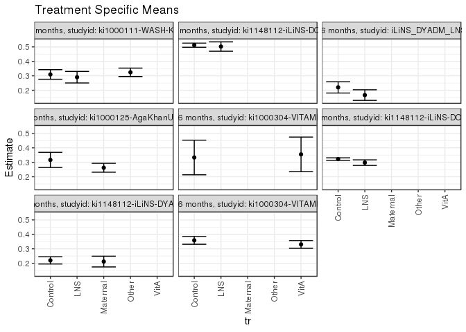

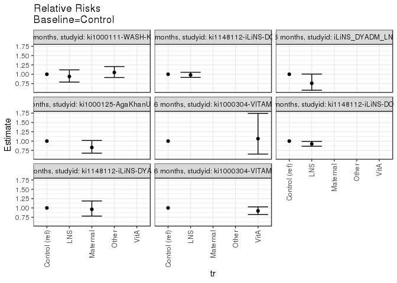

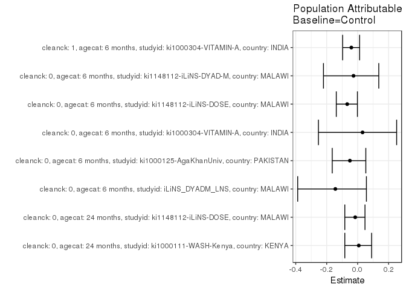

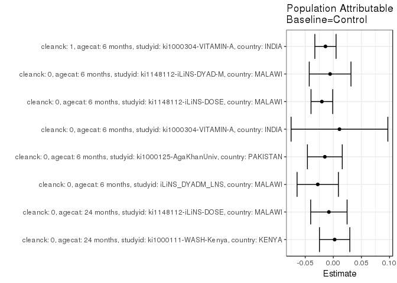

## Results Table

### Parameter: TSM

| cleanck | agecat | studyid | country | intervention_level | baseline_level | estimate | ci_lower | ci_upper |
| --- | --- | --- | --- | --- | --- | --- | --- | --- |
| 0 | 6 months | iLiNS_DYADM_LNS | MALAWI | Control | NA | 0.2200000 | 0.1808718 | 0.2591282 |
| 0 | 6 months | iLiNS_DYADM_LNS | MALAWI | LNS | NA | 0.1666667 | 0.1300839 | 0.2032495 |
| 0 | 6 months | ki1000125-AgaKhanUniv | PAKISTAN | Control | NA | 0.3164557 | 0.2640153 | 0.3688961 |
| 0 | 6 months | ki1000125-AgaKhanUniv | PAKISTAN | Maternal | NA | 0.2622951 | 0.2314775 | 0.2931127 |
| 0 | 6 months | ki1000304-VITAMIN-A | INDIA | Control | NA | 0.3333333 | 0.2135618 | 0.4531048 |
| 0 | 6 months | ki1000304-VITAMIN-A | INDIA | VitA | NA | 0.3548387 | 0.2352503 | 0.4744271 |
| 0 | 6 months | ki1148112-iLiNS-DOSE | MALAWI | Control | NA | 0.3222591 | 0.3134379 | 0.3310804 |
| 0 | 6 months | ki1148112-iLiNS-DOSE | MALAWI | LNS | NA | 0.2978015 | 0.2785263 | 0.3170766 |
| 0 | 6 months | ki1148112-iLiNS-DYAD-M | MALAWI | Control | NA | 0.2200000 | 0.1947462 | 0.2452538 |
| 0 | 6 months | ki1148112-iLiNS-DYAD-M | MALAWI | Maternal | NA | 0.2117117 | 0.1746044 | 0.2488190 |
| 0 | 24 months | ki1000111-WASH-Kenya | KENYA | Control | NA | 0.3093333 | 0.2762459 | 0.3424207 |
| 0 | 24 months | ki1000111-WASH-Kenya | KENYA | LNS | NA | 0.2903226 | 0.2503672 | 0.3302780 |
| 0 | 24 months | ki1000111-WASH-Kenya | KENYA | Other | NA | 0.3241870 | 0.2949348 | 0.3534392 |
| 0 | 24 months | ki1148112-iLiNS-DOSE | MALAWI | Control | NA | 0.5118110 | 0.4973881 | 0.5262340 |
| 0 | 24 months | ki1148112-iLiNS-DOSE | MALAWI | LNS | NA | 0.5023474 | 0.4699867 | 0.5347082 |
| 1 | 6 months | ki1000304-VITAMIN-A | INDIA | Control | NA | 0.3585062 | 0.3314236 | 0.3855888 |
| 1 | 6 months | ki1000304-VITAMIN-A | INDIA | VitA | NA | 0.3302286 | 0.3034008 | 0.3570564 |

### Parameter: E(Y)

| cleanck | agecat | studyid | country | intervention_level | baseline_level | estimate | ci_lower | ci_upper |
| --- | --- | --- | --- | --- | --- | --- | --- | --- |
| 0 | 6 months | iLiNS_DYADM_LNS | MALAWI | NA | NA | 0.1923077 | 0.1386188 | 0.2459966 |
| 0 | 6 months | ki1000125-AgaKhanUniv | PAKISTAN | NA | NA | 0.3013699 | 0.2404592 | 0.3622805 |
| 0 | 6 months | ki1000304-VITAMIN-A | INDIA | NA | NA | 0.3442623 | 0.2596048 | 0.4289198 |
| 0 | 6 months | ki1148112-iLiNS-DOSE | MALAWI | NA | NA | 0.3018868 | 0.2806848 | 0.3230888 |
| 0 | 6 months | ki1148112-iLiNS-DYAD-M | MALAWI | NA | NA | 0.2142857 | 0.1693983 | 0.2591731 |
| 0 | 24 months | ki1000111-WASH-Kenya | KENYA | NA | NA | 0.3116592 | 0.2924312 | 0.3308872 |
| 0 | 24 months | ki1148112-iLiNS-DOSE | MALAWI | NA | NA | 0.5039164 | 0.4684862 | 0.5393467 |
| 1 | 6 months | ki1000304-VITAMIN-A | INDIA | NA | NA | 0.3445096 | 0.3254380 | 0.3635813 |

### Parameter: RR

| cleanck | agecat | studyid | country | intervention_level | baseline_level | estimate | ci_lower | ci_upper |
| --- | --- | --- | --- | --- | --- | --- | --- | --- |
| 0 | 6 months | iLiNS_DYADM_LNS | MALAWI | Control | Control | 1.0000000 | 1.0000000 | 1.0000000 |
| 0 | 6 months | iLiNS_DYADM_LNS | MALAWI | LNS | Control | 0.7575758 | 0.5711286 | 1.0048893 |
| 0 | 6 months | ki1000125-AgaKhanUniv | PAKISTAN | Control | Control | 1.0000000 | 1.0000000 | 1.0000000 |
| 0 | 6 months | ki1000125-AgaKhanUniv | PAKISTAN | Maternal | Control | 0.8288525 | 0.6764813 | 1.0155438 |
| 0 | 6 months | ki1000304-VITAMIN-A | INDIA | Control | Control | 1.0000000 | 1.0000000 | 1.0000000 |
| 0 | 6 months | ki1000304-VITAMIN-A | INDIA | VitA | Control | 1.0645161 | 0.6504336 | 1.7422141 |
| 0 | 6 months | ki1148112-iLiNS-DOSE | MALAWI | Control | Control | 1.0000000 | 1.0000000 | 1.0000000 |
| 0 | 6 months | ki1148112-iLiNS-DOSE | MALAWI | LNS | Control | 0.9241056 | 0.8613933 | 0.9913835 |
| 0 | 6 months | ki1148112-iLiNS-DYAD-M | MALAWI | Control | Control | 1.0000000 | 1.0000000 | 1.0000000 |
| 0 | 6 months | ki1148112-iLiNS-DYAD-M | MALAWI | Maternal | Control | 0.9623260 | 0.7804234 | 1.1866267 |
| 0 | 24 months | ki1000111-WASH-Kenya | KENYA | Control | Control | 1.0000000 | 1.0000000 | 1.0000000 |
| 0 | 24 months | ki1000111-WASH-Kenya | KENYA | LNS | Control | 0.9385428 | 0.7884155 | 1.1172568 |
| 0 | 24 months | ki1000111-WASH-Kenya | KENYA | Other | Control | 1.0480183 | 0.9111583 | 1.2054353 |
| 0 | 24 months | ki1148112-iLiNS-DOSE | MALAWI | Control | Control | 1.0000000 | 1.0000000 | 1.0000000 |
| 0 | 24 months | ki1148112-iLiNS-DOSE | MALAWI | LNS | Control | 0.9815096 | 0.9148669 | 1.0530068 |
| 1 | 6 months | ki1000304-VITAMIN-A | INDIA | Control | Control | 1.0000000 | 1.0000000 | 1.0000000 |
| 1 | 6 months | ki1000304-VITAMIN-A | INDIA | VitA | Control | 0.9211238 | 0.8244026 | 1.0291926 |

### Parameter: PAR

| cleanck | agecat | studyid | country | intervention_level | baseline_level | estimate | ci_lower | ci_upper |
| --- | --- | --- | --- | --- | --- | --- | --- | --- |
| 0 | 6 months | iLiNS_DYADM_LNS | MALAWI | Control | NA | -0.0276923 | -0.0644548 | 0.0090701 |
| 0 | 6 months | ki1000125-AgaKhanUniv | PAKISTAN | Control | NA | -0.0150858 | -0.0460715 | 0.0158999 |
| 0 | 6 months | ki1000304-VITAMIN-A | INDIA | Control | NA | 0.0109290 | -0.0751062 | 0.0969641 |
| 0 | 6 months | ki1148112-iLiNS-DOSE | MALAWI | Control | NA | -0.0203723 | -0.0396521 | -0.0010926 |
| 0 | 6 months | ki1148112-iLiNS-DYAD-M | MALAWI | Control | NA | -0.0057143 | -0.0428239 | 0.0313954 |
| 0 | 24 months | ki1000111-WASH-Kenya | KENYA | Control | NA | 0.0023259 | -0.0246574 | 0.0293091 |
| 0 | 24 months | ki1148112-iLiNS-DOSE | MALAWI | Control | NA | -0.0078946 | -0.0402563 | 0.0244671 |
| 1 | 6 months | ki1000304-VITAMIN-A | INDIA | Control | NA | -0.0139966 | -0.0328738 | 0.0048806 |

### Parameter: PAF

| cleanck | agecat | studyid | country | intervention_level | baseline_level | estimate | ci_lower | ci_upper |
| --- | --- | --- | --- | --- | --- | --- | --- | --- |
| 0 | 6 months | iLiNS_DYADM_LNS | MALAWI | Control | NA | -0.1440000 | -0.3873614 | 0.0566726 |
| 0 | 6 months | ki1000125-AgaKhanUniv | PAKISTAN | Control | NA | -0.0500575 | -0.1641547 | 0.0528571 |
| 0 | 6 months | ki1000304-VITAMIN-A | INDIA | Control | NA | 0.0317460 | -0.2533836 | 0.2520121 |
| 0 | 6 months | ki1148112-iLiNS-DOSE | MALAWI | Control | NA | -0.0674834 | -0.1379117 | -0.0014140 |
| 0 | 6 months | ki1148112-iLiNS-DYAD-M | MALAWI | Control | NA | -0.0266667 | -0.2208200 | 0.1366094 |
| 0 | 24 months | ki1000111-WASH-Kenya | KENYA | Control | NA | 0.0074628 | -0.0830048 | 0.0903734 |
| 0 | 24 months | ki1148112-iLiNS-DOSE | MALAWI | Control | NA | -0.0156664 | -0.0830346 | 0.0475112 |
| 1 | 6 months | ki1000304-VITAMIN-A | INDIA | Control | NA | -0.0406276 | -0.0968948 | 0.0127534 |